**Introduction to Machine Learning**

**Midterm Exam**

|  | by Prof. Seungchul Lee iSystems Design Lab http://isystems.unist.ac.kr/ UNIST |
| --- | --- |

# Problem 1

**(a)**

Let $f$ be a reflection transformation. To prove that $f$ is linear, we need to show

$$ \begin{align*} f(\alpha x_1) &= \alpha \,f(x_1) \\ f(x_1 + x_2) &= f(x_1) + f(x_2) \end{align*}$$

[figure not shown]

By the above figure, the linearity is obvious.

**(b)**

Suppose that $\omega$ is a projection vector of $x$ onto $v$.

[figure not shown]

**(c)**

From geometirc interpretation, we know that $\omega$ and $x - \omega$ are eigenvectors of the reflection transformation and the corresponding eigenvalues are $1$ and $-1$ repectively. Let $P$ be a reflection matrix. Then,

$$ \begin{align*} Px &= \lambda_1 \omega + \lambda_2 (x - \omega) \\ & = 1 \cdot \omega + (-1) \cdot (x - \omega) \\ &= 2 \omega - x \end{align*} $$

the rest of calculation is the sames as **(b)**.

**(d)**

Plug $v = \begin{bmatrix}1\\ 1\end{bmatrix}$ into the result of **(b)**, then it gives

$$ M = 2\frac{\begin{bmatrix}1\\ 1 \end{bmatrix}\begin{bmatrix}1&1\end{bmatrix}}{\begin{bmatrix}1& 1 \end{bmatrix}\begin{bmatrix}1 \\ 1\end{bmatrix}} - \begin{bmatrix} 1 & 0 \\ 0 & 1 \end{bmatrix} = \begin{bmatrix} 0 & 1 \\ 1 & 0 \end{bmatrix} $$

[figure not shown]

$$\begin{align*} \text{if } x = \begin{bmatrix} x_1\\ x_2 \end{bmatrix} &\implies Z = \begin{bmatrix} 0 & 1 \\ 1 & 0 \end{bmatrix}\begin{bmatrix} x_1\\ x_2 \end{bmatrix} = \begin{bmatrix} x_2\\ x_1 \end{bmatrix}\\\\ Mx = \lambda x &\implies \left(M - \lambda I \right)x = 0\\\\ \text{det} \begin{bmatrix}-\lambda & 1 \\ 1 & -\lambda \end{bmatrix} &= \lambda^2 - 1 = 0 \implies \lambda = \pm 1 \end{align*}$$$$\begin{align*} &\text{For } \lambda_1 = 1, x_1 = \begin{bmatrix}1 \\ 1 \end{bmatrix}\\ &\text{For } \lambda_2 = -1, x_2 = \begin{bmatrix}1 \\ -1 \end{bmatrix}\\ \end{align*}$$

# Problem 2

**(a)**

A rotation does not change the magnitude of a vector. Hence,

$$\begin{align*} \Vert Rx \Vert_2^2 = \Vert x \Vert_2^2 &\implies x^TR^TRx = x^Tx, \ \forall x \in \mathbb{R}^n \\ &\implies x^T(R^TR - I)x=0, \ \forall x \in \mathbb{R}^n \\ &\implies R^TR = I \end{align*}$$

**(b)**

From **(a)** we can see that

$$R^TR = I \implies R^{-1} = R^T$$

Also, since an inverse function is unique (or from geometric intuition),

$$R^{-1}(\theta) = R(-\theta)$$

**(c)**

The result is obvious from **(a)**.

# Problem 3

**(a)**

For an arbitrary vector $\mathbf{x}$, $A_1$ transforms it (here, $n=3$) as

$$ A_1\mathbf{x} = \begin{bmatrix} 0 & 1 & 0\\ 0 & 0 & 1\\ 1 & 0 & 0 \end{bmatrix} \begin{bmatrix} x_1\\ x_2\\ x_3 \end{bmatrix} = \begin{bmatrix} x_2\\ x_3\\ x_1 \end{bmatrix} $$

which implies it permutes the elements of $\mathbf{x}$.

**(b)**

We need to show columns of a permutation matrix $A$ are orthogonal to each other.

Let $a_i$ and $a_j$ be $i$-th and $j$-th columns of the $A$ ($i \neq j$). Since 1) positions of one in each columns are different and 2) each column contains a single one, $$ a_i^{T}a_j = 0. $$

Hence, a permutation matrix is orthogonal.

**(c)**

By **(b)**, $g(f(x))\implies A^TA = AA^T = I$. Hence $g$ is an inverse function of $f$.

**(d)**

By **(a)**, ones in each row and column of matrix $A$ have the following meanings:

- one in $i$-th column indicates where the element $x_i$ to go
- one in $j$-th row indicates where the transformed vector $A\mathbf{x}$'s $j$-th element comes from.

Therefore, ones in each row and column of the transposed matrix $A^T$ have the reversed meanings:

- one in $j$-th column indicates where the transformed vector $A\mathbf{x}$'s $j$-th element comes from.
- one in $i$-th row indicates where the element $x_i$ to go.

which is equivalent explanation of inverse transformation.

# Problem 4

**(a)**

Sum of 2-norms of multiple vectors can be expressed as a 2-norm of a single vector.

$$ \begin{align*} \left\Vert A\theta - y\big\Vert^2_{2} + \big\Vert \sqrt{\lambda}I\theta-0\right\Vert^2_{2} & = \Bigg\Vert \begin{bmatrix} A\\ \sqrt{\lambda}I \end{bmatrix} \theta- \begin{bmatrix} y\\ 0 \end{bmatrix} \Bigg\Vert^2_{2} \end{align*}$$$$ \hat{\theta} = \left( \begin{bmatrix} A\\ \sqrt{\lambda}I \end{bmatrix}^T \begin{bmatrix} A\\ \sqrt{\lambda}I \end{bmatrix}\right)^{-1}\begin{bmatrix} A\\ \sqrt{\lambda}I \end{bmatrix}^T \begin{bmatrix} y\\ 0 \end{bmatrix} = \left( A^T A + \lambda I_n \right)^{-1} A^T y $$

**(b)**

Let $J(\theta) = \Vert A\theta - y \Vert_2^2 + \lambda \Vert \theta \Vert_2^2$. A gradient descent algorithm is formulated as the following,

$$ \theta \leftarrow \theta - \eta \frac{\partial{J}}{\partial{\theta}}. $$

Need to compute $\frac{\partial{J}}{\partial{\theta}}$.

$$ \begin{align*} g_{\text{projection}} &= \frac{\partial}{\partial{\theta}} \Vert A\theta - y \Vert_2^2 \\ &= \frac{\partial}{\partial{\theta}} (A\theta - y)^T(A\theta - y) \\ &= \frac{\partial}{\partial{\theta}} (\theta^T A^T A \theta - 2\theta^T A^T y - y^Ty) \\ &= 2A^TA \theta - 2A^Ty \\ \\ g_{\text{regularizer}} &= \frac{\partial}{\partial{\theta}} \Vert \theta \Vert_2^2 \\ &= \frac{\partial}{\partial{\theta}} \theta^T \theta \\ &= 2 \theta. \end{align*} $$

Therefore,

$$ \begin{align*} \frac{\partial{J}}{\partial{\theta}} &= g_{\text{projection}} + \lambda g_{\text{regularizer}} \\ &= 2A^TA \theta - 2A^Ty + \lambda 2 \theta. \end{align*} $$

Then, the gradient descent algorithm is formulated as the following

$$ \theta \leftarrow \theta - \eta(2A^TA \theta - 2A^Ty + \lambda 2 \theta). $$

**(c)**

[figure not shown]

$g_{\text{regularizer}}$ make $\theta$ converge to zero. Since $g = g_{\text{projection}} + \lambda g_{\text{regularizer}}$, we can see that regularizer underestimates the value of the projection.

**(d)**

Likewise, **(a)** shows that the regularizer underestimates the value of projection by

$$ (A^T A)^{-1} A^Ty \rightarrow (A^T A + \lambda I_n)^{-1} A^Ty. $$

**(e)**

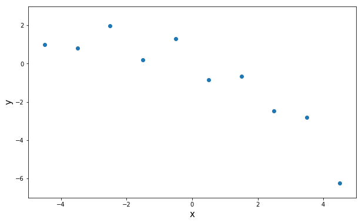

```python
import numpy as np
import matplotlib.pyplot as plt

x = np.linspace(-4.5, 4.5, 10)
y = np.array([0.9819, 0.7973, 1.9737, 0.1838, 1.3180, -0.8361, -0.6591, -2.4701, -2.8122, -6.2512])

plt.figure(figsize=(10, 6))
plt.plot(x, y, 'o')
plt.xlabel('x', fontsize=15)
plt.ylabel('y', fontsize=15)
plt.xlim(-5, 5)
plt.ylim(-7, 3)
plt.show()
```

```
[[ 0.10833274]
 [-0.70202688]
 [-0.1193053 ]]
```

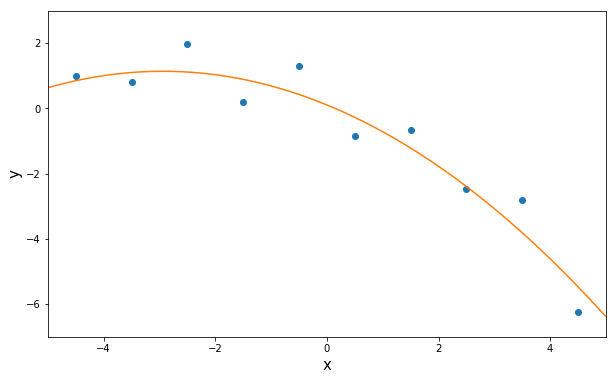

```python
x = np.array(x).reshape(-1, 1)
y = np.array(y).reshape(-1, 1)
A = np.hstack([x**0, x, x**2])
A = np.asmatrix(A)
theta = np.zeros([3, 1])
alpha = 0.000001
lamb = 1

for i in range(100000):
    g = A.T*A*theta - A.T*y + lamb*theta
    theta = theta - alpha*g

print(theta)

xp = np.arange(-5,5,0.01).reshape(-1,1)
yp = theta[0,0] + theta[1,0]*xp + theta[2,0]*xp**2

plt.figure(figsize=(10, 6))
plt.plot(x, y, 'o')
plt.plot(xp[:,0], yp[:,0])
plt.xlabel('x', fontsize=15)
plt.ylabel('y', fontsize=15)
plt.xlim(-5, 5)
plt.ylim(-7, 3)
plt.show()
```

# Problem 5

**(a)**

Let's denote $\mathbf{x}_{-j}$ the vector $\mathbf{x}$ without the $j$-th element $x_j$. $ P(y \mid \mathbf{x}) = P(y \mid \mathbf{x}_{-j}) $ indicates $y$ is independent of $x_{j}$. Hence $x_j$ is a useless feature.

**(b)**

Without loss of generality, let's assume $j$-th value of the sparse vector $\omega$ is zero. Then,

$$\begin{align*} P(y\mid\mathbf{x}) &= f(x;\omega) \\ &= f(x;\omega_{-j}) \\ &= P(y\mid\mathbf{x}_{-j}) \end{align*}$$

Therefore, Lasso selects meaningful features.

**(c)**

```python
from six.moves import cPickle
x = cPickle.load(open('./data/data_input.pkl', 'rb'))
y = cPickle.load(open('./data/data_target.pkl', 'rb'))
```

```python
# Write your code here
import cvxpy as cvx

y = y.reshape(506,1)
n_data = 506
d = 13

lamb = 2
theta = cvx.Variable(d, 1)
obj = cvx.Minimize(cvx.sum_squares(x*theta - y) + lamb*cvx.norm(theta, 1))
prob = cvx.Problem(obj).solve('SCS')
```

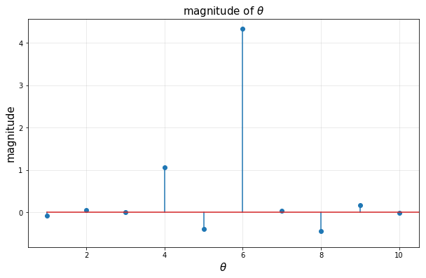

```python
# Regulization ( = ridge nonlinear regression) encourages small weights, but not exactly 0
plt.figure(figsize=(10, 6))
plt.title(r'magnitude of $\theta$', fontsize=15)
plt.xlabel(r'$\theta$', fontsize=15)
plt.ylabel('magnitude', fontsize=15)
plt.stem(np.linspace(1, 13, 13).reshape(-1, 1), theta.value)
plt.xlim([0.5, 10.5])
plt.grid(alpha=0.3)
plt.show()
```

**(d)**

```python
#Write your code here
d = 13
features = [13]
elim_idx = [False]*13
elim_num = 0
lamb = 2
x_selected = x.copy()

for i in range(5):
    theta = cvx.Variable(d, 1)
    obj = cvx.Minimize(cvx.sum_squares(x_selected*theta - y) + lamb*cvx.norm(theta, 1))
    prob = cvx.Problem(obj).solve('SCS')

    for j in range(d):
        if abs(theta.value[j]) < 0.01:
            if elim_idx[j] == False:
                elim_idx[j] = True
                elim_num += 1
                x_selected[:,j] = np.zeros(x_selected.shape[0])
    features.append(d - elim_num)
```

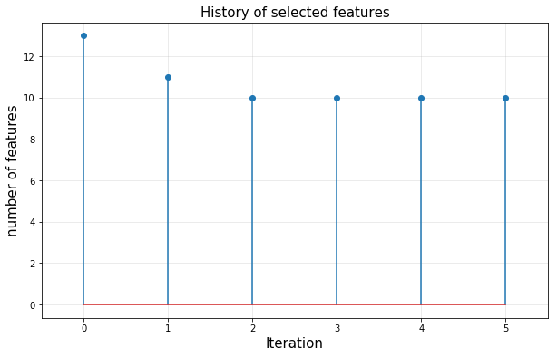

```python
plt.figure(figsize=(10, 6))
plt.title(r'History of selected features', fontsize=15)
plt.xlabel('Iteration', fontsize=15)
plt.ylabel('number of features', fontsize=15)
plt.stem(np.linspace(0, 5, 6).reshape(-1, 1), features)
plt.xlim([-0.5,5.5])
plt.grid(alpha=0.3)
plt.show()
```

# Problem6

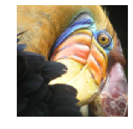

```
Matrix shape: (128, 128, 3)
```

```python
from six.moves import cPickle
import matplotlib.pyplot as plt

A = cPickle.load(open('./data/bird.pkl', 'rb'))

plt.figure(figsize=(4, 4))
plt.imshow(A.astype('uint8'))
plt.axis('off')
plt.show()

print('Matrix shape: {}'.format(A.shape))
```

```python
# Write down your code here

k = 16
A_re = A.reshape(128*128,3)
centroid = np.array([np.linspace(5, 255, k), np.linspace(5, 255, k), np.linspace(5, 255, k)]).T
mu = centroid.copy()

y = np.empty([128*128, 1])
d = np.zeros([k,1])

for n_iter in range(10):
    for i in range(128*128):
        for j in range(k):
            d[j] = np.linalg.norm(A_re[i,:] - mu[j,:], 2)
        y[i] = np.argmin(d)

    err = 0
    for i in range(k):
        mu[i,:] = np.mean(A_re[np.where(y == i)[0]], axis=0)
        err += np.linalg.norm(centroid[i,:] - mu[i,:],2)

    centroid = mu.copy()
    print("Iteration : {0}/{1}, err : {2}".format(n_iter+1, 10, err))
    if err < 1e-10:
        print("Iteration:", n_iter)
        break

img = np.zeros([128*128, 3])

for i in range(16):
    img[np.where(y[:,0] == i)] = centroid[i]
```

```
Iteration : 1/10, err : 502.83625127080626
Iteration : 2/10, err : 130.27782022936955
Iteration : 3/10, err : 167.98678545461357
Iteration : 4/10, err : 64.65594727843731
Iteration : 5/10, err : 39.90913727379131
Iteration : 6/10, err : 39.08137279763004
Iteration : 7/10, err : 39.40752526191003
Iteration : 8/10, err : 40.014691012938016
Iteration : 9/10, err : 37.137936083585046
Iteration : 10/10, err : 28.949098937074094
```

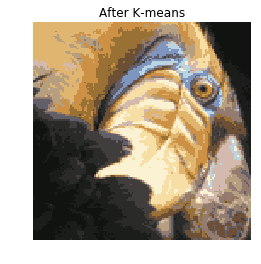

```python
plt.figure(figsize=(4, 4))

plt.title('After K-means')
plt.imshow(img.reshape(128,128,3).astype('uint8'))
plt.axis('off')
plt.show()
```